# Ocupação e política: profissões dos candidatos como medida de análise da baixa representação de candidaturas pretas à Câmara dos Deputados em 2022.

Carlos Jacomes

2024-09-05

# Resumo

A finalidade desta nota técnica é apresentar, a partir da classificação das ocupações dos candidatos fatores que podem ajudar a explicar a continuidade da baixa representação de candidaturas pretas à Câmara dos Deputados. Por meio da análise de dados quantitativos, a nota busca identificar se existe relação entre ocupação e classe na eleição dos deputados federais eleitos em 2022 para a Câmara dos Deputados. Os dados quantitativos trabalhados no documento corroboram com a percepção de que ocupações de maior prestígio social e econômico estão correlacionadas com maiores taxas de sucesso eleitoral.

# Introdução

O processo eleitoral e os espaços de tomada de decisão são alguns dos elementos que compõem a representação política. Ainda assim, a representação eleitoral, enquanto subconjunto das relações representativas em que o representado autoriza o representador, é um dos pilares da noção de produção de legitimidade nas democracias liberais. A legitimidade democrática é caracterizada pelo sistema eleitoral. Além de construir um governo ou uma oposição, as preferências do eleitor são representadas em uma eleição pois, em tese, todos participam para a criação de um órgão representativo universal (Urbinati, Warren, 2008).

No entanto, a representação eleitoral não dá conta de representar a totalidade e complexidade dos grupos políticos, e parcelas significativas da sociedade não são incluídas diretamente no processo institucional decisório (Urbinati, Warren, 2008; Norris, 2013). A representação política da população preta e pobre nas instituições políticas, tema tocante a esta nota técnica, segue sendo um dos principais dilemas democráticos no caso brasileiro.

Nesse sentido, as eleições de 2022 contaram com 10.630 candidatos, cerca de 2 mil candidatos a mais que o pleito passado (2018), em que foram registrados 8.588, segundo levantamento feito pela Câmara dos Deputados com base nos dados do Tribunal Superior Eleitoral (TSE). O registro geral das candidaturas reafirma o que tem sido levantado por diversos pesquisadores (Gaxie, 2012; Rodrigues,2006; Santos, 1997; Marques, 2012; Norris & Lovenduski, 1995), os eleitos seguem sendo os indivíduos que ocupam posições altas na classe social, ou seja, os eleitos seguem sendo os empresários ou pessoas que exercem posições mais reconhecidas e mais bem remuneradas no mercado de trabalho.

Speck e Sachet (2012) entendem que as variáveis exógenas influenciam as disputas eleitorais, a exemplo de questões socioeconômicas como a ocupação dos candidatos, variável que pode colocar um candidato em vantagem em detrimento de outro. Dependendo do grau de ocupação dos candidatos é possível afirmar, de modo grosseiro, que a desigualdade na disputa pelo voto poderá ser um fator relevante na análise da disputa por um pleito eleitoral.

Além do grau de ocupação, a variável raça também pode ser um elemento complementar para mensurar desigualdades. Os indivíduos que ocupam posições mais baixas de classe e exercem atividades menos reconhecidas seguem não conquistando os pleitos eleitorais. Os números mostram ainda que os dados de ocupação evidenciam a sub-representação de negros na Câmara dos Deputados em relação ao conjunto populacional de negros no Brasil.

Dessa forma, a presente nota técnica tem por objetivo analisar, a partir da classificação das ocupações dos candidatos que concorreram as eleições de 2022 à Câmara dos Deputados, se os dados reafirmam a sub-representação de candidaturas pretas e pobres.

# Método

Com objetivo de avaliar a relação entre a ocupação e a classe dos candidatos com seu sucesso eleitoral, além da representação racial, a base de dados do TSE foi utilizada para realização da classificação das ocupações dos candidatos ao pleito de 2022. Essa classificação foi feita considerando os seguintes dados extraídos do TSE: total de candidaturas registradas na plataforma; todas as ocupações registradas no Tribunal; a classificação das ocupações com base na tabela utilizada por Campos e Machado (2020) e; situação de totalização das candidaturas. Eles se basearam na sociologia da estratificação social brasileira e adotaram cinco categorias para realizar essa classificação:

1. Classe baixa – trabalhadore(a)s rurais, manuais e doméstico(a)s, artesãos(ãs) e técnico(a)s de escritório com pouca formação;
2. Classe média baixa – técnico(a)s com formação superior, artistas, funcionário(a)s público(a)s de baixo escalão e comerciantes;
3. Classe média alta – profissionais diplomado(a)s no Ensino Superior, funcionário(a)s público(a)s de médio escalão e pequeno(a)s empresário(a)s;
4. Classe alta – político(a)s já eleito(a)s para outro cargo, grandes empresário(a)s e funcionário(a)s público(a)s que ocupam carreiras de Estado;
5. Outro(a)s – ocupações não classificadas na base do TSE.

A partir da classificação das ocupações foi possível entender o perfil dos candidatos a partir de uma perspectiva de classe. Verificando o encaixe populacional dos candidatos e a taxa de sucesso dos eleitos e não eleitos, foi possível constatar ainda a cor dos candidatos.

Por meio dessas informações, foram levantados números que mostram a distribuição das candidaturas considerando a ocupação dos candidatos, raça e classe, bem como do percentual das candidaturas comparando os candidatos eleitos, não eleitos e a cor dos respectivos candidatos. Os dados mostram, por exemplo, que candidatos de classe alta e média alta possuem maior sucesso eleitoral, e que há uma sub-representação de candidatos negros e pardos entre os eleitos.

Para mobilizar essa argumentação foram testadas 3 hipóteses para verificar a significância das diferenças observadas a partir da base de dados:

# Análise

## Sub-representação de candidaturas sob a perspectiva de raça e classe

Para entender um pouco dos problemas da sub-representação de negros na política brasileira é importante passar sobre as considerações de Jairo Nicolau (2006), que tratou sobre a personificação de campanhas gerada pelo sistema eleitoral de lista aberta, que enfraquece partidos políticos e seu sistema de votos, até as literaturas sobre recrutamento político, em que Pippa Norris e Joni Lovenduski (1993, 2004) chegaram a conclusão de que o recrutamento político precisa democratizar as decisões, aumentar a transparência e controle público sobre os partidos. Com esses avanços seria possível pensar em diminuir desigualdades entre grupos tipicamente fragilizados no processo de recrutamento e o acesso maior ao financiamento eleitoral.

Historicamente, pretos e pardos estão sub-representados no Congresso Nacional em relação aos números populacionais no Brasil. Essa sub-representação está ligada a alguns fatores políticos e culturais que vão desde as mudanças sistêmicas que o modelo eleitoral brasileiro passou, a redemocratização do país e as dificuldades que candidaturas pretas enfrentam em razão do enfrentamento entre brancos e pretos para disputa de poder. O fortalecimento de políticos negros ao longo dos anos, mais especificamente entre 1983 e 1999, passou por um longo período de adaptação do debate da questão racial no cenário político, haja vista que existia dificuldade até para os próprios políticos pretos de tomarem a frente dos debates (Johnson, 2000).

Além dessa adaptação, a precarização do financiamento dessas candidaturas fez com que elas fossem realizadas de forma ineficiente. Durante esse período estudado por Johnson (2000), as candidaturas negras eram mais aceitas na Bahia e Rio de Janeiro, estados historicamente povoados por pessoas pretas, mas também por partidos ligados ao espectro político de esquerda, como PT e o PDT. No entanto, as candidaturas eram majoritariamente masculinas, dentro do recorte de raça (Johnson, 2000).

Tomando como base a literatura e fazendo uma breve análise exploratória dos dados levantados na base do TSE, é possível observar que o volume de candidatos não eleitos é maior entre as candidaturas não brancas, enquanto brancos possuem maioria entre os eleitos, seja por média ou por quoeficiente partidário. Em percentuais, o gráfico mostra que 58,23% dos candidatos não brancos não foram eleitos, enquanto 41,77% dos canddiatos brancos não foram eleitos. Sobre os eleitos, se somarmos eleitos por média e eleitos entre os brancos, os dados mostram que 52,05% foram eleitos enquanto 24,56% foram eleitos para o cargo de deputado federal, considerando a situação de totalização das eleições de 2022.

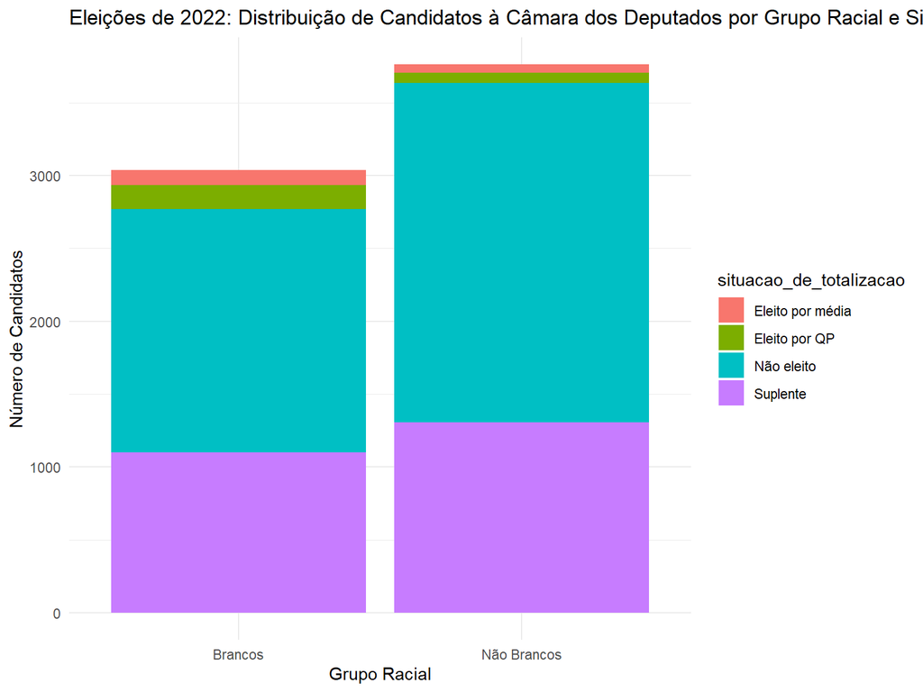

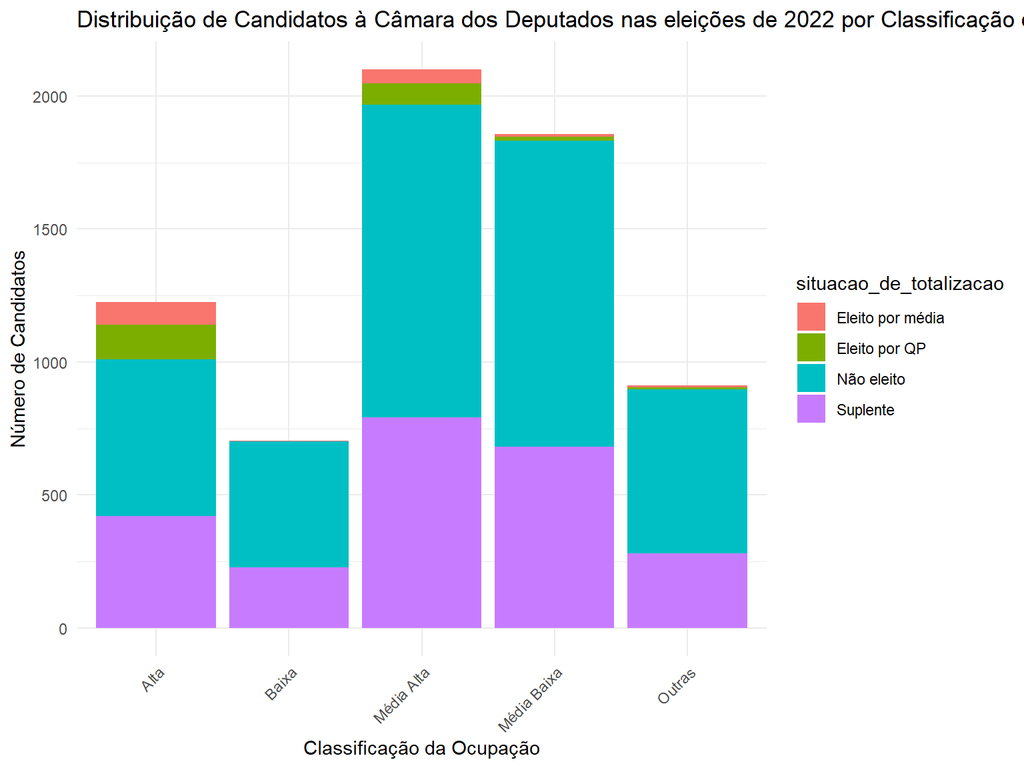

Os dados alertam ainda para diferença entre a taxa de sucesso de brancos e não brancos, especialmente quando analisamos o cruzamento dos dados de grupos raciais e as ocupações, em que brancos de classe alta e média alta possuem maiores taxas de sucesso eleitoral que candidatos não brancos com ocupação baixa e média baixa. O gráfico mostra que 23,10% dos candidatos brancos de classe “alta” foram eleitos enquanto 11,80% dos candidatos não brancos e da mesma classe obtiveram sucesso eleitoral.

Já nas ocupações classificadas como “baixa”, 0,45% dos candidatos brancos foram eleitos enquanto 0,21% dos candidatos não brancos tiveram sucesso nas urnas, indicando um percentual baixo tanto em brancos como em não brancos em razão da ocupação dos candidatos serem classificadas como “baixa”. Os dados indicam que há dificuldade de sucesso eleitoral entre candidados que possuem ocupações periféricas.

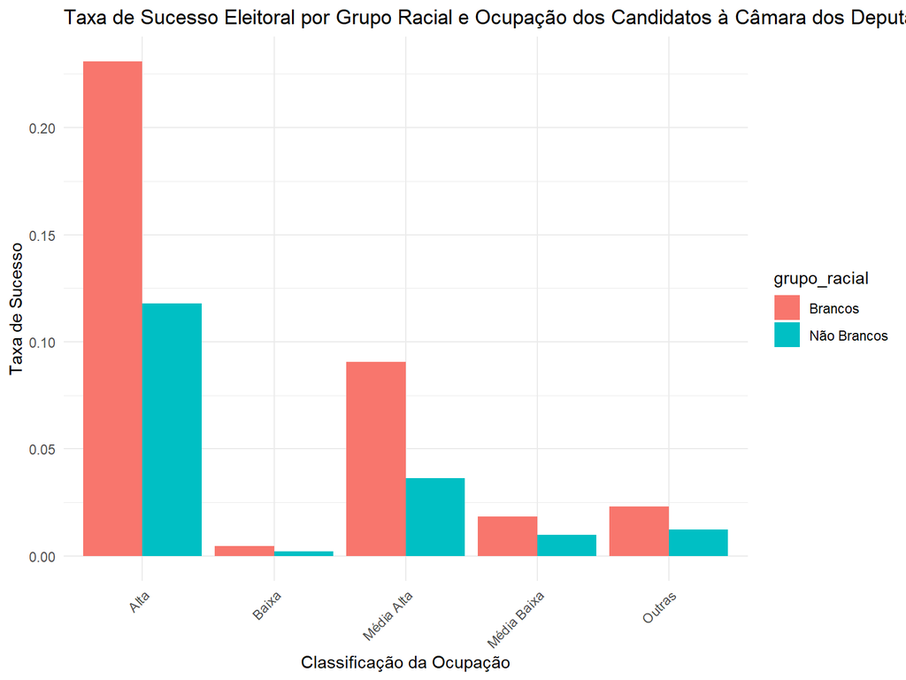

De acordo com a literatura especializada, a precarização do financiamento dessas candidaturas fez com que elas fossem realizadas de forma ineficiente. Durante esse período estudado por Johnson (2000), as candidaturas negras eram mais aceitas na Bahia e Rio de Janeiro, estados historicamente povoados por pessoas pretas, mas também por partidos ligados ao espectro político de esquerda, como PT e o PDT. No entanto, as candidaturas eram majoritariamente masculinas, dentro do recorte de raça (Johnson, 2000).

Sobre a ausência de financiamento a candidaturas negras, Campos e Carlos Machado (2020) se desdobram sobre as dificuldades de identificar se o problema da sub-representação de negros é uma questão de raça ou de classe social, haja vista que a população negra majoritariamente integra as classes sociais mais baixas. A partir deste argumento, os autores resolveram trabalhar com o conceito de dividir as candidaturas baseadas em suas posições de trabalho no mercado, tendo em vista que algumas profissões, como a de médico e advogado, podem contribuir para o desenvolvimento comunicativo de candidatos, levando esses profissionais a alcançarem cargos políticos. Nesse sentido a população negra, que é historicamente desassistida de políticas de saúde e educação, por não integrarem posições de trabalho no mercado, sofrem dificuldades de ingressarem na política institucional.

Sacchet (2012) trabalha com o argumento de que a democracia precisa ser pensada a partir do atendimento de interesses de todos os cidadãos, considerando as diferenças do indivíduo. Desse modo, a busca por uma equidade de raça, assim como se tem pensado a equidade de gênero, pode contribuir com a promoção de políticas igualitárias, além de fazer com que se chegue o mais perto de contemplar diversos interesses.

## Taxa de sucesso eleitoral por classificação da ocupação

Luiz Augusto Campos e Carlos Machado (2015) abordaram a questão do capital simbólico como uma narrativa que pode ser explorada para explicar a importância do nível de instrução dos candidatos, bem como a origem de classe e gênero, no sucesso eleitoral dos que se propõem a concorrer em uma disputa eleitoral. Tendo como base o patrimônio dos candidatos nas eleições municipais no Rio de Janeiro e em São Paulo em 2012, os dados mostram que brancos e não brancos sempre ficam distantes quando é comparada a renda média dos candidatos, sendo que os brancos sempre lideram o ranking de quem mais possui renda enquanto os não brancos lideram na ausência de patrimônio. Além dos recursos financeiros, os autores apontam o nível de escolaridade como fator importante, dada a construção de redes que a obtenção de um nível de escolaridade pode proporcionar (Campos, Machado, 2015).

Se pensarmos na classificação das ocupações, grande parte dos candidatos possuem ocupações que dependem de um certo grau de escolaridade, a exemplo de advogados, médicos, juízes, psicólogos e demais profissionais que no momento de sua formação construíram redes que ampliaram de certa forma suas chances de atingirem um pleito eleitoral.

Na visão de Natália Bueno, raça se tornou um fator relevante em seus estudos quando comparada com classe, ou seja, com a posição social dos candidatos. Além disso, a autora considera relevante levar com consideração habilidades que podem ser desenvolvidas por esses grupos raciais. A autora analisou a influência da raça na participação política em Belo Horizonte (MG) e, na conjuntura local, constatou que raça é útil na análise quando considerada em conjunto com fatores socioeconômicos externos como renda e escolaridade (Bueno, 2012). Apesar da resposta ter um direcionamento à realidade de Belo Horizonte, convergiu com o objetivo desta nota técnica em analisar a sub-representação de candidatos pretos e pardos a partir da ocupação dos candidatos.

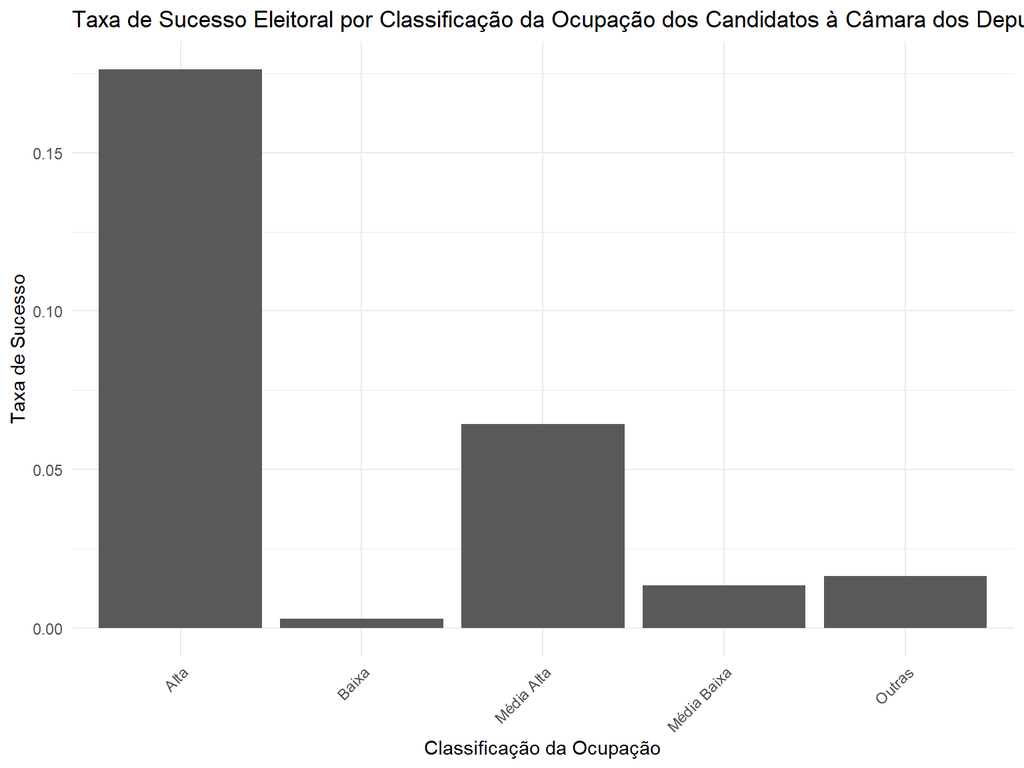

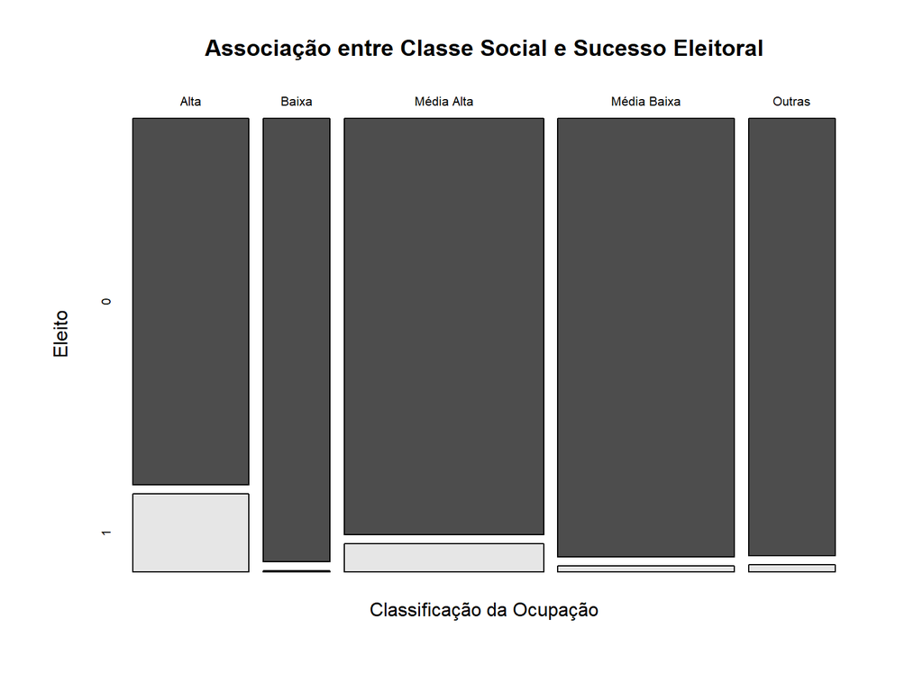

```
## Participação de negros e pardos nas candidaturas: 0.5449331
```

```
## Participação de negros e pardos entre os eleitos: 0.307888
```

[figure not shown]

Com objetivo de analisar se a ocupação dos candidatos influencia suas chances de sucesso eleitoral, com profissões de maior prestígio social e econômico correlacionadas com maiores taxas de sucesso, os dados apontam para influência da ocupação dos candidatos naschances de sucesso eleitoral, e as ocupações associadas a maior prestígio social e econômico (como a ocupação “alta”) têm maiores taxas de sucesso eleitoral. Isso sugere que candidatos de ocupações de maior prestígio têm mais chances de serem eleitos, enquanto aqueles de ocupações menos prestigiadas têm menos chances.

O gráfico corrobora a conclusão da regressão logística de que ocupações de maior prestígio social e econômico estão correlacionadas com maiores taxas de sucesso eleitoral. Este gráfico vislumbra a forte correlação entre o prestígio da ocupação e a probabilidade de sucesso nas eleições, dando suporte visual à última hipótese levantada por essa nota técnica.

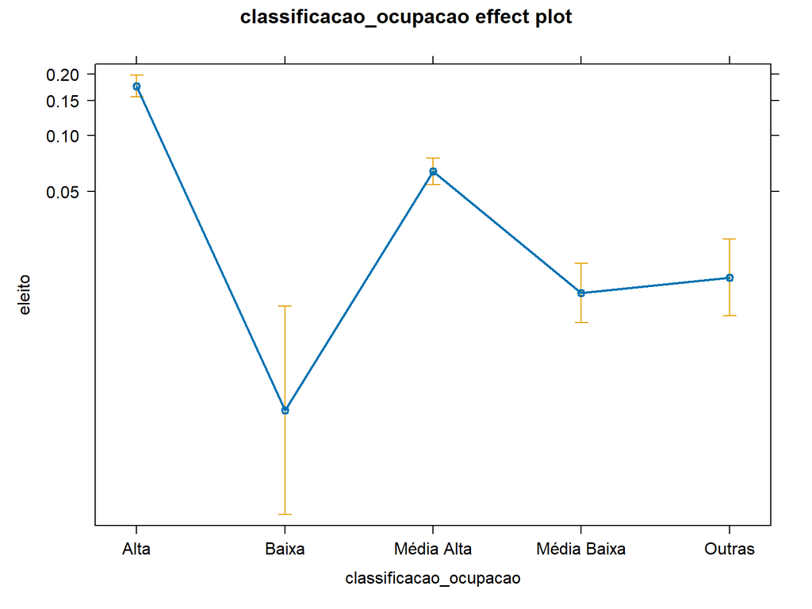

# Conclusão

As candidaturas brancas e pretas bem como as estratificações sociais ao qual elas são inseridas precisam ser levadas em consideração quando analisamos candidatos aos diversos cargos eletivos, pois não existe igualdade entre os candidatos na disputa por um pleito eleitoral. As diferenças vão desde a escolaridade dos candidatos, suas profissões e o patrimônio financeiro de cada um, fatores que influenciam na influência política sobre o eleitorado.

Os resultados da relação entre ocupação e raça mostraram que esses dois fatores são importantes para mensurar a falta de sucesso de candidatos que exercem profissões enquadradas nas categorias de classe baixa e média baixa. Os candidatos das categorias altas e médias altas, apesar de sua posição social não garantirem uma vaga direta à Câmara dos Deputados, aumentam as chances desses candidatos de conseguirem atingir o pleito.

Desse modo, os resultados obtidos através da classificação dos candidatos mostraram que a ascensão de candidaturas de classe média alta e de classe alta mostram que profissões que contribuem para o desenvolvimento comunicativo dos candidatos aliado ao capital econômico adquirido pelos mesmos potencializam suas chances de atingir o pleito eleitoral.

Com isso, a população preta e pobre segue aumentando o número de candidaturas, mas as chances de atingir o pleito eleitoral seguem estáveis, tendo em vista que são carentes de políticas públicas de atenção à saúde e educação no Brasil. Essa carência dificulta a saída desses indivíduos de posições mais baixas no mercado de trabalho, fazendo com que sigam integrando as ocupações mais baixas.

# Referências Bibliográficas

BUENO, Natália Salgado. Raça e comportamento político: participação, ativismo e recursos em Belo Horizonte. Lua Nova, São Paulo, n. 85, p. 187-226, 2012.

CAMPOS, Luiz Augusto; MACHADO, Carlos. Raça e Eleições no Brasil. 1. ed. Porto Alegre: Zouk, 2020. v. 1. 168p.

NICOLAU, Jairo. (2006). Sistema Eleitoral de Lista Aberta no Brasil. Dados-revista De Ciencias Sociais - DADOS-REV CIENC SOC. 49. 10.1590/S0011-52582006000400002.

NORRIS, Pippa. Recrutamento Político. Revista de Sociologia e Política, 21 (46), 11 32. 2013.

OLLIE A. Johnson III. Representação racial e política no Brasil: parlamentares negros no Congresso Nacional (1983-99). Journal of Interamerican Studies and World Affairs, 40. 2000.

SACCHET, TERESA. Representação política, representação de grupos e política de cotas: perspectivas e contendas feministas. ESTUDOS FEMINISTAS, v. 20, p. 399-431, 2012.

SACCHET, TERESA. Why gender quotas don´t work in Brazil? The role of the electoral system and political finance. COLOMBIA INTERNACIONAL, v. 95, p. 25-54, 2018.

SPECK, Bruno Wilhelm; SACCHET, Teresa. Patrimônio, instrução e ocupação dos candidatos: uma análise das candidaturas de mulheres e homens nas eleições gerais de 2010 no Brasil. In: ALVES, José Eustáquio Diniz; PINTO, Céli Regina Jardim; JORDÃO, Fátima (Org.). Mulheres nas eleições de 2010. São Paulo, ABCP, 2012. p.167-206.

URBINATI, Nadia; WARREN, Mark E. The concept of representation in contemporary democratic theory. Annual Review of Political Science, v. 11, p. 387–412, 2008.

Fonte: Campos, Luiz Augusto; Machado, Carlos. Raça e Eleições no Brasil (2020)